# surfaces1

## Exercise of Surfaces (I) in SageMath - Differential Geometry

### *Questions:*

Consider the surface $S$ with equation $z=x y (x^2-y^2)$.

1. Given $r>0$, find the curve $\gamma_r$ in $S$ whose orthogonal projection onto the plane $z=0$ is the circumference of centre $(0,0,0)$ and radius $r$.
2. Plot the surface with some curves $\gamma_r$.
3. Compute the first fundamental form, and multiples of the second fundamental form and the Weingarten map which do not contain roots.
4. Determine the type of the points in $S$.
5. Compute the Gaussian curvature and the mean curvature.
6. Find some asymptotic curves.
7. Compute the normal curvature and the geodesic curvature of the curves $\gamma_r$.
8. Plot and compute numerically the area of the region of $S$ whose orthogonal projection onto the plane $z=0$ is the disk of centre $(0,0,0)$ and radius $r$.

### *Solution:*

We define the variables

```python
var('u,v,r,t,x,y,z', domain='real')
```

```
(u, v, r, t, x, y, z)
```

We are going to assign $x$ and $y$ two independent parameters and $z$ will be determined by the equation above. Then, we consider the following parametrization where $u\in\mathbb{R}$, $v\in\mathbb{R}$:

$$x=u$$$$y=v$$$$z=uv(u^2-v^2)$$

And we define the surface $S$.

```python
V = vector([u,v,u*v*(u^2-v^2)])
S = ParametrizedSurface3D(V,(u,v),name='Surface')
```

$$\mathbf{x}(u,v)=(u,v,uv(u^2-v^2))$$

#### Question 1: Given $r>0$, find the curve $\gamma_r$ in $S$ whose orthogonal projection onto the plane $z=0$ is the circumference of centre $(0,0,0)$ and radius $r$.

We know that a circumference with centre $(0,0,0)$ and radius $r$ on the plane $z=0$ can be parametrized with a parameter $t\in [0,2\pi]$ in the following way:

$$x=r\cos(t)$$$$y=r\sin(t)$$$$z=0$$

For any other value of $z=z(t)$, the curve will be deformed, but its projection onto $z=0$ will still be a circumference because of the choice of $x$ and $y$. In particular, if the curve has to be contained in the surface $S$, we must choose

$$x=u=r\cos(t)$$$$y=v=r\sin(t)$$$$z=uv(u^2-v^2)=r\cos(t)\cdot r\sin(t)\cdot \left[r^2\cos^2(t)-r^2\sin^2(t)\right]$$

```python
polar = {u:r*cos(t),v:r*sin(t)}
parampolar= vector([u,v]).subs(polar)
gamma = S.point(parampolar)
show(gamma)
```

\[\newcommand{\Bold}[1]{\mathbf{#1}}\left(r \cos\left(t\right),\,r \sin\left(t\right),\,{\left(r^{2} \cos\left(t\right)^{2} - r^{2} \sin\left(t\right)^{2}\right)} r^{2} \cos\left(t\right) \sin\left(t\right)\right)\]

#### Question 2: Plot the surface with some curves $\gamma_r$.

For the surface, we will use the function `plot` of the object `ParametrizedSurface3D` previously defined. For the curves, we substitute 4 different radii (for example, $r=0.5$, $r=1.0$, $r=1.5$ and $r=2.0$) and we plot with `parametric_plot3d` along with the surface.

```python
surf = S.plot((-2,2),(-2,2),frame=False)

gamma1 = parametric_plot3d(gamma.subs(r=0.5),(t,0,2*pi),color='red') # r = 0.5
gamma2 = parametric_plot3d(gamma.subs(r=1.0),(t,0,2*pi),color='red') # r = 1.0
gamma3 = parametric_plot3d(gamma.subs(r=1.5),(t,0,2*pi),color='red') # r = 1.5
gamma4 = parametric_plot3d(gamma.subs(r=2.0),(t,0,2*pi),color='red') # r = 2.0

show(surf+gamma1+gamma2+gamma3+gamma4)
```

[interactive chart not shown]

#### Question 3: Compute the first fundamental form, and multiples of the second fundamental form and the Weingarten map which do not contain roots.

The first fundamental form is given by the following scalar products:

$$ \mathbf{I}_{\mathbf{x}}= \begin{pmatrix} \langle\mathbf{x}_u , \mathbf{x}_u\rangle & \langle\mathbf{x}_u , \mathbf{x}_v\rangle \\ \langle\mathbf{x}_v , \mathbf{x}_u\rangle & \langle\mathbf{x}_v , \mathbf{x}_v\rangle \end{pmatrix} = \begin{pmatrix} E & F \\ F & G \end{pmatrix} $$

where $\mathbf{x}_u = \frac{\partial \mathbf{x}}{\partial u}$ and $\mathbf{x}_v = \frac{\partial \mathbf{x}}{\partial v}$.

Nevertheless, we may use the function `first_fundamental_form_coefficients` of the object `ParametrizedSurface3D` to obtain the 4 coefficients and build the matrix.

```python
first = S.first_fundamental_form_coefficients()
FF1 = Matrix(2,[first[i,j].factor() for i in [1,2] for j in [1,2]])
show(FF1)
```

\[\newcommand{\Bold}[1]{\mathbf{#1}}\left(\begin{array}{rr} 9 \, u^{4} v^{2} - 6 \, u^{2} v^{4} + v^{6} + 1 & {\left(3 \, u^{2} - v^{2}\right)} {\left(u^{2} - 3 \, v^{2}\right)} u v \\ {\left(3 \, u^{2} - v^{2}\right)} {\left(u^{2} - 3 \, v^{2}\right)} u v & u^{6} - 6 \, u^{4} v^{2} + 9 \, u^{2} v^{4} + 1 \end{array}\right)\]

The second fundamental form is given by

$$ \mathbf{II}_{\mathbf{x}}= \begin{pmatrix} \langle\mathbf{x}_{uu} , \mathbf{N}_{\mathbf{x}}\rangle & \langle\mathbf{x}_{uv} , \mathbf{N}_{\mathbf{x}}\rangle \\ \langle\mathbf{x}_{vu} , \mathbf{N}_{\mathbf{x}}\rangle & \langle\mathbf{x}_{vv} , \mathbf{N}_{\mathbf{x}}\rangle \end{pmatrix} = \begin{pmatrix} e & f \\ f & g \end{pmatrix} $$

where

$\mathbf{x}_{uu} = \frac{\partial^2 \mathbf{x}}{\partial u^2}$,

$\mathbf{x}_{uv} = \mathbf{x}_{vu} = \frac{\partial^2 \mathbf{x}}{\partial u \partial v}$,

$\mathbf{x}_{vv} = \frac{\partial^2 \mathbf{x}}{\partial v^2}$

and $\mathbf{N}_{\mathbf{x}}$ is the normal vector to the surface.

We get the second fundamental form with `second_fundamental_form_coefficients`.

```python
second = S.second_fundamental_form_coefficients()
FF2 = Matrix(2,[second[i,j].factor() for i in [1,2] for j in [1,2]])
show(FF2)
```

\[\newcommand{\Bold}[1]{\mathbf{#1}}\left(\begin{array}{rr} \frac{6 \, u v}{\sqrt{u^{4} + v^{4} + {\left(2 \, u^{2} - 1\right)} v^{2} - u^{2} + 1} \sqrt{u^{2} + v^{2} + 1}} & \frac{3 \, {\left(u + v\right)} {\left(u - v\right)}}{\sqrt{u^{4} + v^{4} + {\left(2 \, u^{2} - 1\right)} v^{2} - u^{2} + 1} \sqrt{u^{2} + v^{2} + 1}} \\ \frac{3 \, {\left(u + v\right)} {\left(u - v\right)}}{\sqrt{u^{4} + v^{4} + {\left(2 \, u^{2} - 1\right)} v^{2} - u^{2} + 1} \sqrt{u^{2} + v^{2} + 1}} & -\frac{6 \, u v}{\sqrt{u^{4} + v^{4} + {\left(2 \, u^{2} - 1\right)} v^{2} - u^{2} + 1} \sqrt{u^{2} + v^{2} + 1}} \end{array}\right)\]

We see that the roots are in the denominator of each term and all of them have the same denominator. Then, we have to multiply the second fundamental form by that factor to obtain a matrix without roots:

```python
show(sqrt(u^4+v^4+(2*u^2-1)*v^2-u^2+1)*sqrt(u^2+v^2+1)*FF2)
```

\[\newcommand{\Bold}[1]{\mathbf{#1}}\left(\begin{array}{rr} 6 \, u v & 3 \, {\left(u + v\right)} {\left(u - v\right)} \\ 3 \, {\left(u + v\right)} {\left(u - v\right)} & -6 \, u v \end{array}\right)\]

The Weingarten map is

$$\mathcal{W}_{\mathbf{x}}=\mathbf{I}_{\mathbf{x}}^{-1}\mathbf{II}_{\mathbf{x}}$$

In SageMath, we get it with `shape_operator`.

```python
weingarten = S.shape_operator().apply_map(factor)
show(weingarten)
```

\[\newcommand{\Bold}[1]{\mathbf{#1}}\left(\begin{array}{rr} -\frac{3 \, {\left(u^{6} - u^{4} v^{2} - 5 \, u^{2} v^{4} - 3 \, v^{6} - 2\right)} \sqrt{u^{4} + v^{4} + {\left(2 \, u^{2} - 1\right)} v^{2} - u^{2} + 1} u v}{{\left(u^{4} + 2 \, u^{2} v^{2} + v^{4} - u^{2} - v^{2} + 1\right)}^{2} {\left(u^{2} + v^{2} + 1\right)}^{\frac{3}{2}}} & \frac{3 \, {\left(u^{8} - u^{6} v^{2} - 5 \, u^{4} v^{4} - 3 \, u^{2} v^{6} + u^{2} - v^{2}\right)} \sqrt{u^{4} + v^{4} + {\left(2 \, u^{2} - 1\right)} v^{2} - u^{2} + 1}}{{\left(u^{4} + 2 \, u^{2} v^{2} + v^{4} - u^{2} - v^{2} + 1\right)}^{2} {\left(u^{2} + v^{2} + 1\right)}^{\frac{3}{2}}} \\ \frac{3 \, {\left(3 \, u^{6} v^{2} + 5 \, u^{4} v^{4} + u^{2} v^{6} - v^{8} + u^{2} - v^{2}\right)} \sqrt{u^{4} + v^{4} + {\left(2 \, u^{2} - 1\right)} v^{2} - u^{2} + 1}}{{\left(u^{4} + 2 \, u^{2} v^{2} + v^{4} - u^{2} - v^{2} + 1\right)}^{2} {\left(u^{2} + v^{2} + 1\right)}^{\frac{3}{2}}} & -\frac{3 \, {\left(3 \, u^{6} + 5 \, u^{4} v^{2} + u^{2} v^{4} - v^{6} + 2\right)} \sqrt{u^{4} + v^{4} + {\left(2 \, u^{2} - 1\right)} v^{2} - u^{2} + 1} u v}{{\left(u^{4} + 2 \, u^{2} v^{2} + v^{4} - u^{2} - v^{2} + 1\right)}^{2} {\left(u^{2} + v^{2} + 1\right)}^{\frac{3}{2}}} \end{array}\right)\]

```python
weingarten == FF1^(-1)*FF2
```

```
True
```

Since $\mathbf{I}_{\mathbf{x}}$ has no roots, neither does its inverse. Therefore, looking at the formula of $\mathcal{W}_{\mathbf{x}}$, the same factor that removes roots in $\mathbf{II}_{\mathbf{x}}$ also does in $\mathcal{W}_{\mathbf{x}}$.

```python
show(sqrt(u^4+v^4+(2*u^2-1)*v^2-u^2+1)*sqrt(u^2+v^2+1)*weingarten)
```

\[\newcommand{\Bold}[1]{\mathbf{#1}}\left(\begin{array}{rr} -\frac{3 \, {\left(u^{6} - u^{4} v^{2} - 5 \, u^{2} v^{4} - 3 \, v^{6} - 2\right)} {\left(u^{4} + v^{4} + {\left(2 \, u^{2} - 1\right)} v^{2} - u^{2} + 1\right)} u v}{{\left(u^{4} + 2 \, u^{2} v^{2} + v^{4} - u^{2} - v^{2} + 1\right)}^{2} {\left(u^{2} + v^{2} + 1\right)}} & \frac{3 \, {\left(u^{8} - u^{6} v^{2} - 5 \, u^{4} v^{4} - 3 \, u^{2} v^{6} + u^{2} - v^{2}\right)} {\left(u^{4} + v^{4} + {\left(2 \, u^{2} - 1\right)} v^{2} - u^{2} + 1\right)}}{{\left(u^{4} + 2 \, u^{2} v^{2} + v^{4} - u^{2} - v^{2} + 1\right)}^{2} {\left(u^{2} + v^{2} + 1\right)}} \\ \frac{3 \, {\left(3 \, u^{6} v^{2} + 5 \, u^{4} v^{4} + u^{2} v^{6} - v^{8} + u^{2} - v^{2}\right)} {\left(u^{4} + v^{4} + {\left(2 \, u^{2} - 1\right)} v^{2} - u^{2} + 1\right)}}{{\left(u^{4} + 2 \, u^{2} v^{2} + v^{4} - u^{2} - v^{2} + 1\right)}^{2} {\left(u^{2} + v^{2} + 1\right)}} & -\frac{3 \, {\left(3 \, u^{6} + 5 \, u^{4} v^{2} + u^{2} v^{4} - v^{6} + 2\right)} {\left(u^{4} + v^{4} + {\left(2 \, u^{2} - 1\right)} v^{2} - u^{2} + 1\right)} u v}{{\left(u^{4} + 2 \, u^{2} v^{2} + v^{4} - u^{2} - v^{2} + 1\right)}^{2} {\left(u^{2} + v^{2} + 1\right)}} \end{array}\right)\]

#### Question 4: Determine the type of the points in $S$.

A point in a surface is:

• **elliptic** if both principal curvatures have the same sign.

• **hyperbolic** if both principal curvatures have a different sign.

• **parabolic** if exactly one of the two principal curvatures is not zero.

• **planar** if both principal curvatures are zero.

We obtain both principal curvatures $k_1$ and $k_2$ with `principal_directions`

```python
k1 = S.principal_directions()[0][0]
show(k1)
```

\[\newcommand{\Bold}[1]{\mathbf{#1}}-\frac{3 \, {\left(2 \, {\left(u^{7} v + u^{5} v^{3} - u^{3} v^{5} - u v^{7}\right)} \sqrt{u^{4} + v^{4} + {\left(2 \, u^{2} - 1\right)} v^{2} - u^{2} + 1} \sqrt{u^{2} + v^{2} + 1} + \sqrt{12 \, u^{4} v^{14} + 4 \, u^{2} v^{16} + {\left(4 \, u^{6} + 1\right)} v^{12} + u^{12} - 10 \, {\left(2 \, u^{8} - u^{2}\right)} v^{10} - 5 \, {\left(4 \, u^{10} - 3 \, u^{4}\right)} v^{8} + 2 \, {\left(2 \, u^{12} + 6 \, u^{6} + 1\right)} v^{6} + 2 \, u^{6} + 3 \, {\left(4 \, u^{14} + 5 \, u^{8} + 2 \, u^{2}\right)} v^{4} + 2 \, {\left(2 \, u^{16} + 5 \, u^{10} + 3 \, u^{4}\right)} v^{2} + 1} {\left(u^{2} + v^{2}\right)}\right)}}{u^{12} + 15 \, u^{4} v^{8} + 6 \, u^{2} v^{10} + v^{12} + 2 \, {\left(10 \, u^{6} + 1\right)} v^{6} + 2 \, u^{6} + 3 \, {\left(5 \, u^{8} + 2 \, u^{2}\right)} v^{4} + 6 \, {\left(u^{10} + u^{4}\right)} v^{2} + 1}\]

```python
k2 = S.principal_directions()[1][0]
show(k2)
```

\[\newcommand{\Bold}[1]{\mathbf{#1}}-\frac{3 \, {\left(2 \, {\left(u^{7} v + u^{5} v^{3} - u^{3} v^{5} - u v^{7}\right)} \sqrt{u^{4} + v^{4} + {\left(2 \, u^{2} - 1\right)} v^{2} - u^{2} + 1} \sqrt{u^{2} + v^{2} + 1} - \sqrt{12 \, u^{4} v^{14} + 4 \, u^{2} v^{16} + {\left(4 \, u^{6} + 1\right)} v^{12} + u^{12} - 10 \, {\left(2 \, u^{8} - u^{2}\right)} v^{10} - 5 \, {\left(4 \, u^{10} - 3 \, u^{4}\right)} v^{8} + 2 \, {\left(2 \, u^{12} + 6 \, u^{6} + 1\right)} v^{6} + 2 \, u^{6} + 3 \, {\left(4 \, u^{14} + 5 \, u^{8} + 2 \, u^{2}\right)} v^{4} + 2 \, {\left(2 \, u^{16} + 5 \, u^{10} + 3 \, u^{4}\right)} v^{2} + 1} {\left(u^{2} + v^{2}\right)}\right)}}{u^{12} + 15 \, u^{4} v^{8} + 6 \, u^{2} v^{10} + v^{12} + 2 \, {\left(10 \, u^{6} + 1\right)} v^{6} + 2 \, u^{6} + 3 \, {\left(5 \, u^{8} + 2 \, u^{2}\right)} v^{4} + 6 \, {\left(u^{10} + u^{4}\right)} v^{2} + 1}\]

Since both expressions are quite complex and we only need information about the signs, it is more convenient to study the product of both principal curvatures.

```python
show((k1*k2).full_simplify())
```

\[\newcommand{\Bold}[1]{\mathbf{#1}}-\frac{9 \, {\left(u^{4} + 2 \, u^{2} v^{2} + v^{4}\right)}}{u^{12} + 15 \, u^{4} v^{8} + 6 \, u^{2} v^{10} + v^{12} + 2 \, {\left(10 \, u^{6} + 1\right)} v^{6} + 2 \, u^{6} + 3 \, {\left(5 \, u^{8} + 2 \, u^{2}\right)} v^{4} + 6 \, {\left(u^{10} + u^{4}\right)} v^{2} + 1}\]

We see a fraction with sums of non-negative terms, and a change of sign ahead. Then, the product of the principal curvatures is always less or equal than zero. It will only be equal to zero when the numerator vanishes, i.e., when $u=v=0$ (the origin). At the rest of the points, the product of the principal curvatures is strictly negative and, therefore, both principal curvatures have a different sign. Thus, all points are **hyperbolic** except the origin. In order to find the type of the origin, we substitute $u=v=0$ in both principal curvatures and we will see if both vanish or only one of them.

```python
show(k1.subs(u=0,v=0))
```

\[\newcommand{\Bold}[1]{\mathbf{#1}}0\]

```python
show(k2.subs(u=0,v=0))
```

\[\newcommand{\Bold}[1]{\mathbf{#1}}0\]

Since both vanish, the origin is **planar**.

#### Question 5: Compute the Gaussian curvature and the mean curvature.

The Gaussian curvature $K$ is

```python
K=(S.gauss_curvature()).factor()
K.show()
```

\[\newcommand{\Bold}[1]{\mathbf{#1}}-\frac{9 \, {\left(u^{2} + v^{2}\right)}^{2}}{{\left(u^{4} + 2 \, u^{2} v^{2} + v^{4} - u^{2} - v^{2} + 1\right)}^{2} {\left(u^{2} + v^{2} + 1\right)}^{2}}\]

It is an expression equivalent to the one obtained before (since $K=k_1 k_2$), although it is more compact and the squares are better grouped.

The mean curvature $H$ is

```python
H=(S.mean_curvature()).factor()
H.show()
```

\[\newcommand{\Bold}[1]{\mathbf{#1}}-\frac{6 \, {\left(u^{2} + v^{2}\right)}^{2} {\left(u + v\right)} {\left(u - v\right)} u v}{{\left(u^{4} + 2 \, u^{2} v^{2} + v^{4} - u^{2} - v^{2} + 1\right)} \sqrt{u^{4} + v^{4} + {\left(2 \, u^{2} - 1\right)} v^{2} - u^{2} + 1} {\left(u^{2} + v^{2} + 1\right)}^{\frac{3}{2}}}\]

which can also be obtained as $H=\frac{k_1+k_2}{2}$.

#### Question 6: Find some asymptotic curves.

We know that a curve $\eta(t)=\mathbf{x}(u(t),v(t))$ is asymptotic if and only if the functions $u(t)$, $v(t)$ satisfy the following differential equation:

$$u'(t)^2e(u(t),v(t)) + 2f(u(t),v(t))u'(t)v'(t) + v'(t)^2g(u(t),v(t)) = 0$$

where $e$, $f$ and $g$ are the coefficients of the second fundamental form (which depend on $u$ and $v$).

The coefficients of the second fundamental form have been computed in *Question 3*:

```python
show(FF2)
```

\[\newcommand{\Bold}[1]{\mathbf{#1}}\left(\begin{array}{rr} \frac{6 \, u v}{\sqrt{u^{4} + v^{4} + {\left(2 \, u^{2} - 1\right)} v^{2} - u^{2} + 1} \sqrt{u^{2} + v^{2} + 1}} & \frac{3 \, {\left(u + v\right)} {\left(u - v\right)}}{\sqrt{u^{4} + v^{4} + {\left(2 \, u^{2} - 1\right)} v^{2} - u^{2} + 1} \sqrt{u^{2} + v^{2} + 1}} \\ \frac{3 \, {\left(u + v\right)} {\left(u - v\right)}}{\sqrt{u^{4} + v^{4} + {\left(2 \, u^{2} - 1\right)} v^{2} - u^{2} + 1} \sqrt{u^{2} + v^{2} + 1}} & -\frac{6 \, u v}{\sqrt{u^{4} + v^{4} + {\left(2 \, u^{2} - 1\right)} v^{2} - u^{2} + 1} \sqrt{u^{2} + v^{2} + 1}} \end{array}\right)\]

Note that we can use any multiple of the second fundamental form since the equation is equal to zero. In particular, the simplest choice is the consideration of the multiple obtained in *Question 3*:

```python
show(sqrt(u^4+v^4+(2*u^2-1)*v^2-u^2+1)*sqrt(u^2+v^2+1)*FF2)
```

\[\newcommand{\Bold}[1]{\mathbf{#1}}\left(\begin{array}{rr} 6 \, u v & 3 \, {\left(u + v\right)} {\left(u - v\right)} \\ 3 \, {\left(u + v\right)} {\left(u - v\right)} & -6 \, u v \end{array}\right)\]

Then, we obtain the following differential equation:

$$6uv(u')^2 + 6(u^2-v^2)u'v' - 6uv(v')^2 = 0$$

Grouping the terms:

$$uv((u')^2-(v')^2) + (u^2-v^2)u'v' = 0$$

Let us try to cancel the two summands separately.

If we take $u(t)=0$, then $u'(t)=0$ and the equation is satisfied. This case corresponds to the coordinate curve $\mathbf{x}(0,v(t))=(0,v(t),0)$ whose trace is a line on the $Y$-axis (direction vector $(0,1,0)$). Since the differential equation above is satisfied, it is an asymptotic curve.

If we take $v(t)=0$, then $v'(t)=0$ and the equation is satisfied. This case corresponds to the coordinate curve $\mathbf{x}(u(t),0)=(u(t),0,0)$ whose trace is a line on the $X$-axis (direction vector $(1,0,0)$). Since the differential equation above is satisfied, it is an asymptotic curve.

We can also take $u^2-v^2=0$ to cancel the second summand. Then, $u=\pm v$ and, therefore, $u'=\pm v'$. Then, $(u')^2 = (v')^2$ and we obtain $(u')^2 - (v')^2 = 0$ which cancels the first summand. Let us fix $u(t)=a(t)$ being $a(t)$ an arbitrary differentiable function. Then, the curve $\mathbf{x}(a(t),a(t))=(a(t),a(t),0)$ is asymptotic and represents a bisector of the $X$ and $Y$ axes on the plane $z=0$ with direction vector $(1,1,0)$. Analogously, the curve $\mathbf{x}(a(t),-a(t))=(a(t),-a(t),0)$ is asymptotic and represents a bisector of the $X$ and $Y$ axes on the plane $z=0$ with direction vector $(1,-1,0)$.

#### Question 7: Compute the normal curvature and the geodesic curvature of the curves $\gamma_r$.

We compute the normal vector to the surface and we substitute the coordinates $u,v$ for the coordinates of the curve $\gamma_r$.

$$\mathbf{N}_{\gamma_r}^S = \frac{\mathbf{x}_u\times \mathbf{x}_v}{||\mathbf{x}_u\times \mathbf{x}_v||}\Bigg\rvert_{u=r\cos(t), v=r\sin(t)}$$

In SageMath, we use the function `normal_vector` and we use polar coordinates for the curves $\gamma_r$.

```python
N_uppercase = S.normal_vector(normalized=True).apply_map(factor).subs(polar)
show(N_uppercase.simplify_full())
```

\[\newcommand{\Bold}[1]{\mathbf{#1}}\left(-\frac{{\left(4 \, r^{3} \cos\left(t\right)^{2} - r^{3}\right)} \sin\left(t\right)}{\sqrt{r^{4} - r^{2} + 1} \sqrt{r^{2} + 1}},\,\frac{4 \, r^{3} \cos\left(t\right) \sin\left(t\right)^{2} - r^{3} \cos\left(t\right)}{\sqrt{r^{4} - r^{2} + 1} \sqrt{r^{2} + 1}},\,\frac{1}{\sqrt{r^{4} - r^{2} + 1} \sqrt{r^{2} + 1}}\right)\]

The tangent vector associated to the curve $\gamma_r$ is

$$\mathbf{t}_{\gamma_r} = \frac{\gamma'_r}{||\gamma'_r||}$$

```python
dgamma = gamma.derivative(t)
tv = dgamma.normalized()
show(tv.simplify_full())
```

\[\newcommand{\Bold}[1]{\mathbf{#1}}\left(-\frac{r \sin\left(t\right)}{\sqrt{64 \, r^{8} \sin\left(t\right)^{8} - 128 \, r^{8} \sin\left(t\right)^{6} + 80 \, r^{8} \sin\left(t\right)^{4} - 16 \, r^{8} \sin\left(t\right)^{2} + r^{8} + r^{2}}},\,\frac{r \cos\left(t\right)}{\sqrt{64 \, r^{8} \sin\left(t\right)^{8} - 128 \, r^{8} \sin\left(t\right)^{6} + 80 \, r^{8} \sin\left(t\right)^{4} - 16 \, r^{8} \sin\left(t\right)^{2} + r^{8} + r^{2}}},\,\frac{8 \, r^{4} \sin\left(t\right)^{4} - 8 \, r^{4} \sin\left(t\right)^{2} + r^{4}}{\sqrt{64 \, r^{8} \sin\left(t\right)^{8} - 128 \, r^{8} \sin\left(t\right)^{6} + 80 \, r^{8} \sin\left(t\right)^{4} - 16 \, r^{8} \sin\left(t\right)^{2} + r^{8} + r^{2}}}\right)\]

With this, we can compute the normal curvature:

$$\kappa_{\gamma_r,n}^S=\frac{\langle\mathbf{t}'_{\gamma_r},\mathbf{N}_{\gamma_r}^S\rangle}{\|{\gamma'_r}\|}$$

```python
knor=(tv.derivative(t)*N_uppercase)/dgamma.norm()
show(knor.simplify_full())
```

\[\newcommand{\Bold}[1]{\mathbf{#1}}-\frac{12 \, {\left(2 \, r^{2} \cos\left(t\right)^{3} - r^{2} \cos\left(t\right)\right)} \sin\left(t\right)}{{\left(64 \, r^{6} \sin\left(t\right)^{8} - 128 \, r^{6} \sin\left(t\right)^{6} + 80 \, r^{6} \sin\left(t\right)^{4} - 16 \, r^{6} \sin\left(t\right)^{2} + r^{6} + 1\right)} \sqrt{r^{4} - r^{2} + 1} \sqrt{r^{2} + 1}}\]

We also compute the vector $\mathbf{n}_{\gamma_r}^S$ with the expression

$$\mathbf{n}_{\gamma_r}^S = \mathbf{N}_{\gamma_r}^S \times \mathbf{t}_{\gamma_r}$$

```python
n_lowercase = N_uppercase.cross_product(tv)
show(n_lowercase.simplify_full())
```

\[\newcommand{\Bold}[1]{\mathbf{#1}}\left(\frac{\sqrt{64 \, r^{8} \sin\left(t\right)^{8} - 128 \, r^{8} \sin\left(t\right)^{6} + 80 \, r^{8} \sin\left(t\right)^{4} - 16 \, r^{8} \sin\left(t\right)^{2} + r^{8} + r^{2}} {\left(32 \, r^{6} \cos\left(t\right) \sin\left(t\right)^{6} - 40 \, r^{6} \cos\left(t\right) \sin\left(t\right)^{4} + 12 \, r^{6} \cos\left(t\right) \sin\left(t\right)^{2} - {\left(r^{6} + 1\right)} \cos\left(t\right)\right)} \sqrt{r^{4} - r^{2} + 1} \sqrt{r^{2} + 1}}{r^{13} + 64 \, {\left(r^{13} + r^{7}\right)} \sin\left(t\right)^{8} + 2 \, r^{7} - 128 \, {\left(r^{13} + r^{7}\right)} \sin\left(t\right)^{6} + 80 \, {\left(r^{13} + r^{7}\right)} \sin\left(t\right)^{4} - 16 \, {\left(r^{13} + r^{7}\right)} \sin\left(t\right)^{2} + r},\,-\frac{\sqrt{64 \, r^{8} \sin\left(t\right)^{8} - 128 \, r^{8} \sin\left(t\right)^{6} + 80 \, r^{8} \sin\left(t\right)^{4} - 16 \, r^{8} \sin\left(t\right)^{2} + r^{8} + r^{2}} {\left(32 \, r^{6} \sin\left(t\right)^{7} - 56 \, r^{6} \sin\left(t\right)^{5} + 28 \, r^{6} \sin\left(t\right)^{3} - {\left(3 \, r^{6} - 1\right)} \sin\left(t\right)\right)} \sqrt{r^{4} - r^{2} + 1} \sqrt{r^{2} + 1}}{r^{13} + 64 \, {\left(r^{13} + r^{7}\right)} \sin\left(t\right)^{8} + 2 \, r^{7} - 128 \, {\left(r^{13} + r^{7}\right)} \sin\left(t\right)^{6} + 80 \, {\left(r^{13} + r^{7}\right)} \sin\left(t\right)^{4} - 16 \, {\left(r^{13} + r^{7}\right)} \sin\left(t\right)^{2} + r},\,\frac{4 \, \sqrt{64 \, r^{8} \sin\left(t\right)^{8} - 128 \, r^{8} \sin\left(t\right)^{6} + 80 \, r^{8} \sin\left(t\right)^{4} - 16 \, r^{8} \sin\left(t\right)^{2} + r^{8} + r^{2}} {\left(2 \, r^{2} \cos\left(t\right) \sin\left(t\right)^{3} - r^{2} \cos\left(t\right) \sin\left(t\right)\right)} \sqrt{r^{4} - r^{2} + 1} \sqrt{r^{2} + 1}}{r^{12} + 64 \, {\left(r^{12} + r^{6}\right)} \sin\left(t\right)^{8} - 128 \, {\left(r^{12} + r^{6}\right)} \sin\left(t\right)^{6} + 2 \, r^{6} + 80 \, {\left(r^{12} + r^{6}\right)} \sin\left(t\right)^{4} - 16 \, {\left(r^{12} + r^{6}\right)} \sin\left(t\right)^{2} + 1}\right)\]

Finally, we compute the geodesic curvature:

$$\kappa_{\gamma_r,g}^S=\frac{\langle\mathbf{t}'_{\gamma_r},\mathbf{n}_{\gamma_r}^S\rangle}{\|{\gamma'_r}\|}$$

```python
kgeod = (tv.derivative(t)*n_lowercase)/dgamma.norm()
show(kgeod.simplify_full())
```

\[\newcommand{\Bold}[1]{\mathbf{#1}}-\frac{{\left(192 \, r^{6} \sin\left(t\right)^{8} - 384 \, r^{6} \sin\left(t\right)^{6} + 240 \, r^{6} \sin\left(t\right)^{4} - 48 \, r^{6} \sin\left(t\right)^{2} - r^{6} - 1\right)} \sqrt{r^{4} - r^{2} + 1} \sqrt{r^{2} + 1}}{\sqrt{64 \, r^{8} \sin\left(t\right)^{8} - 128 \, r^{8} \sin\left(t\right)^{6} + 80 \, r^{8} \sin\left(t\right)^{4} - 16 \, r^{8} \sin\left(t\right)^{2} + r^{8} + r^{2}} {\left(r^{12} + 64 \, {\left(r^{12} + r^{6}\right)} \sin\left(t\right)^{8} - 128 \, {\left(r^{12} + r^{6}\right)} \sin\left(t\right)^{6} + 2 \, r^{6} + 80 \, {\left(r^{12} + r^{6}\right)} \sin\left(t\right)^{4} - 16 \, {\left(r^{12} + r^{6}\right)} \sin\left(t\right)^{2} + 1\right)}}\]

#### Question 8: Plot and compute numerically the area of the region of $S$ whose orthogonal projection onto the plane $z=0$ is the disk of centre $(0,0,0)$ and radius $r$.

We can plot the surface with `plot3d` and add the condition of the disk with `add_condition`. For example, for $r=1$:

```python
z(x,y) = x*y*(x^2-y^2)
r = 1 #Choose the desired radius here

region = plot3d(z, (x, -10, 10), (y, -10, 10), plot_points = 1000)
region = region.add_condition(lambda x,y,z: x^2 + y^2 <= r^2)

show(region)
```

[interactive chart not shown]

The root of the determinant of the first fundamental form is given by `area_form`. With the coordinates $u$, $v$ of the original parametrization, its value is

```python
original_area_function = S.area_form()
show(original_area_function)
```

\[\newcommand{\Bold}[1]{\mathbf{#1}}\sqrt{u^{4} + v^{4} + {\left(2 \, u^{2} - 1\right)} v^{2} - u^{2} + 1} \sqrt{u^{2} + v^{2} + 1}\]

In polar coordinates,

```python
polar_area_function = original_area_function.subs(polar).simplify_full()
show(polar_area_function)
```

\[\newcommand{\Bold}[1]{\mathbf{#1}}\sqrt{r^{4} - r^{2} + 1} \sqrt{r^{2} + 1}\]

In order to compute the area of the region of $S$ whose orthogonal projection onto $z=0$ is the disk of centre $(0,0,0)$ and radius $r$, it will be more convenient to use the version in polar coordinates. This is because it only depends on the radial variable, so the integration with respect to the angular variable is trivial. The area will be

$$\int_0^{2\pi}\int_{0}^r\sqrt{\rho^4-\rho^2+1}\sqrt{\rho^2+1}\ \rho\ \text{d}\rho\ \text{d}t = 2\pi\int_{0}^r\sqrt{\rho^4-\rho^2+1}\sqrt{\rho^2+1}\ \rho\ \text{d}\rho$$

We are going to compute numerically the integral above with `numerical_integral` for many values of $r$ between $0$ and $2$ with a separation of $0.001$. The result is shown in a graph where the area has been plotted against the corresponding value of $r$.

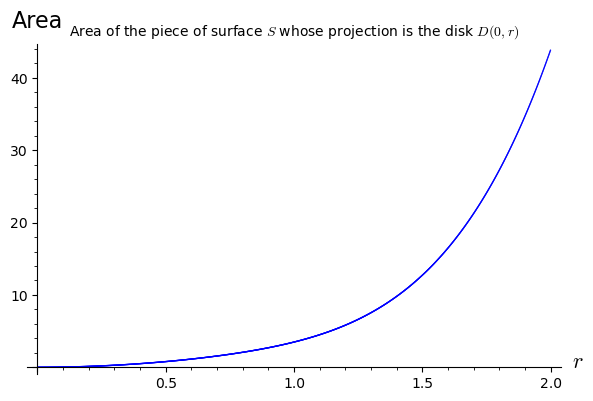

```python
list_r = srange(0,2,0.001)
list_area = []

for i in list_r:
    list_area.append(numerical_approx(2*pi*numerical_integral(sqrt(x^4-x^2+1)*sqrt(x^2+1)*x, 0, i)[0]))

list_r_area = list(zip(list_r,list_area))

p = list_plot(list_r_area,
              size=1,
              title='Area of the piece of surface $S$ whose projection is the disk $D(0,r)$',
              axes_labels=['$r$','Area'])

show(p)
```

Uncomment and run the following line (after having run the previous ones) to see the full list of pairs (r,Area) that form the graph above

```python
#list_r_area
```